# 重賞レース予測レポート【レース終了】

作成日時: 2025/12/14 16:49:08

☞ [マニュアル(pdf)](https://ryutoro-galois.github.io/keiba-predictor/manual/manual.pdf)

☞ 過去5年の同一レース結果: [2024年](https://ryutoro-galois.github.io/keiba-predictor/report/PredResult_2024y_raceDate_20241207_20241208.html), [2023年](https://ryutoro-galois.github.io/keiba-predictor/report/PredResult_2023y_raceDate_20231209_20231210.html), [2022年](https://ryutoro-galois.github.io/keiba-predictor/report/PredResult_2022y_raceDate_20221210_20221211.html), [2021年](https://ryutoro-galois.github.io/keiba-predictor/report/PredResult_2021y_raceDate_20211211_20211212.html), [2020年](https://ryutoro-galois.github.io/keiba-predictor/report/PredResult_2020y_raceDate_20201212_20201213.html)

☞ 過去4週間の別レース結果: [1週前(12/6-7)](https://ryutoro-galois.github.io/keiba-predictor/report/PredResult_2025y_raceDate_20251206_20251207.html), [2週前(11/29-30)](https://ryutoro-galois.github.io/keiba-predictor/report/PredResult_2025y_raceDate_20251129_20251130.html), [3週前(11/22-24)](https://ryutoro-galois.github.io/keiba-predictor/report/PredResult_2025y_raceDate_20251122_20251124.html), [4週前(11/15-16)](https://ryutoro-galois.github.io/keiba-predictor/report/PredResult_2025y_raceDate_20251115_20251116.html)

☞ netkeiba: [中日新聞杯(GⅢ)](https://race.netkeiba.com/race/result.html?race_id=202507050311&rf=race_submenu), [カペラステークス(GⅢ)](https://race.netkeiba.com/race/result.html?race_id=202506050411&rf=race_submenu), [阪神ジュベナイルF(GⅠ)](https://race.netkeiba.com/race/result.html?race_id=202509050411&rf=race_submenu)

☞ レース結果(csv): [12/13-14](https://ryutoro-galois.github.io/keiba-predictor/csv/race_result_20251213_20251214.csv)

## 【レース結果(1)】人気と着順の関係

### 【中日新聞杯(2025/12/13(土))】

【中日新聞杯(GⅢ)】  
2025/12/13(土), 07_中京, 芝左2000m

[interactive chart not shown]

### 【カペラステークス(2025/12/14(日))】

【カペラステークス(GⅢ)】  
2025/12/14(日), 06_中山, ダ右1200m

[interactive chart not shown]

### 【阪神ジュベナイルF(2025/12/14(日))】

【阪神ジュベナイルF(GⅠ)】  
2025/12/14(日), 09_阪神, 芝右外1600m

[interactive chart not shown]

## 【レース結果(2)】コーナー通過順位

### 【中日新聞杯(2025/12/13(土))】

【中日新聞杯(GⅢ)】  
2025/12/13(土), 07_中京, 芝左2000m

[interactive chart not shown]

### 【カペラステークス(2025/12/14(日))】

【カペラステークス(GⅢ)】  
2025/12/14(日), 06_中山, ダ右1200m

[interactive chart not shown]

### 【阪神ジュベナイルF(2025/12/14(日))】

【阪神ジュベナイルF(GⅠ)】  
2025/12/14(日), 09_阪神, 芝右外1600m

[interactive chart not shown]

## 0. 推し馬予測 (AI予測)

### 【中日新聞杯(GⅢ) 2025/12/13(土)】

- 本命(◎): 1-3着内確率(勝負強さ)が1位の馬
- 対抗(◯): 1-3着内確率が2-N位(20%程度以上)の中で予測タイムが最も速い馬
- 3番手(▲): 1-3着内確率が2-N位(20%程度以上)のでダークホース確率が最も高い馬
- 穴: ダークホース確率が上位1-M位(40%程度以上)の中で1-3着内確率が最も高い馬

| 推し馬 | 枠番 | 馬番 | 人気 | オッズ | 馬名 | 騎手 | 調教師 | 予測タイム(sec) | 1_順位 | 1-3着内確率(%) | 2_順位 | ﾀﾞｰｸﾎｰｽ確率(%) | 3_順位 |
| --- | --- | --- | --- | --- | --- | --- | --- | --- | --- | --- | --- | --- | --- |
| 本命(◎) | 5 | 9 | 4 | 6.1 | ピースワンデュック | 柴田善臣 | 大竹正博 | 126.0 | 6 | 50.7 | 1 | 0.6 | 13 |
| 対抗(◯) | 4 | 7 | 7 | 14.8 | レッドバリエンテ | 西村淳也 | 中内田充正 | 118.7 | 3 | 25.6 | 3 | 1.3 | 11 |
| 3番手(▲) | 3 | 6 | 10 | 21.0 | メリオーレム | 武豊 | 友道康夫 | 130.9 | 13 | 22.8 | 6 | 62.6 | 2 |
| 穴 | 1 | 2 | 13 | 110.8 | ウインエーデル | 西塚洸二 | 吉田直弘 | 130.4 | 9 | 9.2 | 11 | 48.6 | 4 |

### 【カペラステークス(GⅢ) 2025/12/14(日)】

- 本命(◎): 1-3着内確率(勝負強さ)が1位の馬
- 対抗(◯): 1-3着内確率が2-N位(20%程度以上)の中で予測タイムが最も速い馬
- 3番手(▲): 1-3着内確率が2-N位(20%程度以上)のでダークホース確率が最も高い馬
- 穴: ダークホース確率が上位1-M位(40%程度以上)の中で1-3着内確率が最も高い馬

| 推し馬 | 枠番 | 馬番 | 人気 | オッズ | 馬名 | 騎手 | 調教師 | 予測タイム(sec) | 1_順位 | 1-3着内確率(%) | 2_順位 | ﾀﾞｰｸﾎｰｽ確率(%) | 3_順位 |
| --- | --- | --- | --- | --- | --- | --- | --- | --- | --- | --- | --- | --- | --- |
| 本命(◎) | 3 | 6 | 2 | 6.1 | ポッドベイダー | 荻野極 | 上原佑紀 | 73.7 | 8 | 46.7 | 1 | 0.7 | 15 |
| 対抗(◯) | 2 | 4 | 1 | 3.9 | テーオーエルビス | 鮫島克駿 | 高柳大輔 | 69.1 | 1 | 28.3 | 4 | 0.5 | 16 |
| 3番手(▲) | 1 | 1 | 6 | 11.0 | ドンアミティエ | 丹内祐次 | 今野貞一 | 73.8 | 10 | 27.0 | 5 | 1.4 | 9 |
| 穴 | 2 | 3 | 16 | 111.9 | スターペスカオリ | 長岡禎仁 | 石橋守 | 73.4 | 7 | 8.3 | 10 | 43.8 | 1 |

### 【阪神ジュベナイルF(GⅠ) 2025/12/14(日)】

- 本命(◎): 1-3着内確率(勝負強さ)が1位の馬
- 対抗(◯): 1-3着内確率が2-N位(20%程度以上)の中で予測タイムが最も速い馬
- 3番手(▲): 1-3着内確率が2-N位(20%程度以上)のでダークホース確率が最も高い馬
- 穴: ダークホース確率が上位1-M位(40%程度以上)の中で1-3着内確率が最も高い馬

| 推し馬 | 枠番 | 馬番 | 人気 | オッズ | 馬名 | 騎手 | 調教師 | 予測タイム(sec) | 1_順位 | 1-3着内確率(%) | 2_順位 | ﾀﾞｰｸﾎｰｽ確率(%) | 3_順位 |
| --- | --- | --- | --- | --- | --- | --- | --- | --- | --- | --- | --- | --- | --- |
| 本命(◎) | 3 | 6 | 2 | 5.3 | アルバンヌ | 坂井瑠星 | 田中博康 | 98.5 | 2.0 | 31.2 | 1 | 4.4 | 14.5 |
| 対抗(◯) | 2 | 4 | 1 | 3.2 | アランカール | 北村友一 | 斉藤崇史 | 93.9 | 1.0 | 24.0 | 8 | 4.4 | 14.5 |
| 3番手(▲) | 8 | 18 | 11 | 62.1 | ショウナンカリス | 池添謙一 | 加藤士津八 | 98.9 | 8.5 | 29.0 | 2 | 61.0 | 7.0 |
| 穴 | 7 | 14 | 10 | 41.9 | スタニングレディ | 和田竜二 | 高木登 | 98.9 | 8.5 | 17.0 | 10 | 59.7 | 9.0 |

## 1. 予測チャート (タイム/勝負強さ)

### 【中日新聞杯(GⅢ)】

2025/12/13(土), 07_中京, 芝左2000m

[interactive chart not shown]

### 【カペラステークス(GⅢ)】

2025/12/14(日), 06_中山, ダ右1200m

[interactive chart not shown]

### 【阪神ジュベナイルF(GⅠ)】

2025/12/14(日), 09_阪神, 芝右外1600m

[interactive chart not shown]

## 2. オッズモニタリング (毎時)

### 【中日新聞杯】

[interactive chart not shown]

### 【カペラステークス】

[interactive chart not shown]

### 【阪神ジュベナイルF】

[interactive chart not shown]

## 3. 出馬表

### 【中日新聞杯 2025/12/13(土) 】

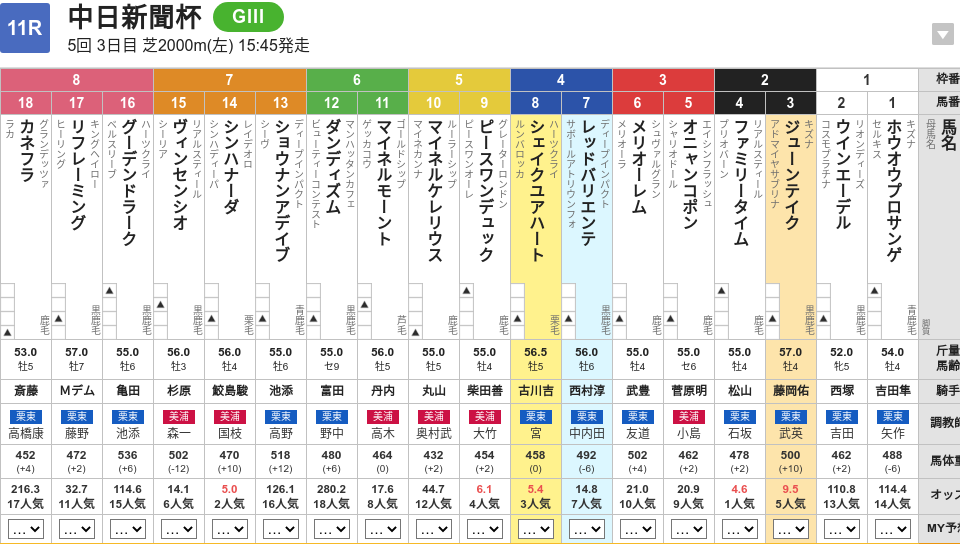

### 【カペラステークス 2025/12/14(日) 】

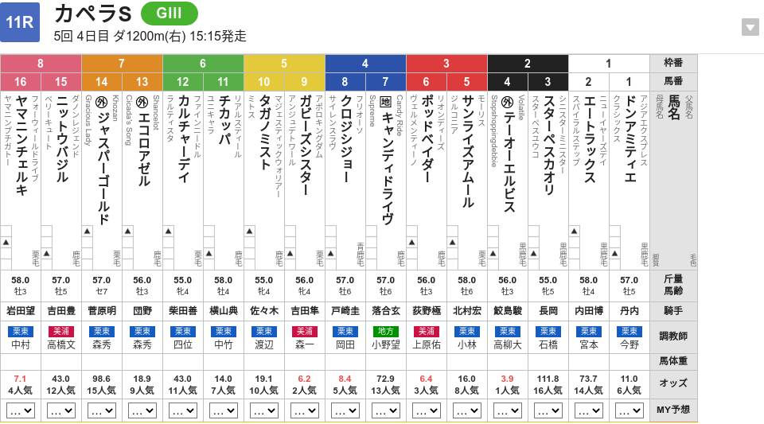

### 【阪神ジュベナイルF 2025/12/14(日) 】

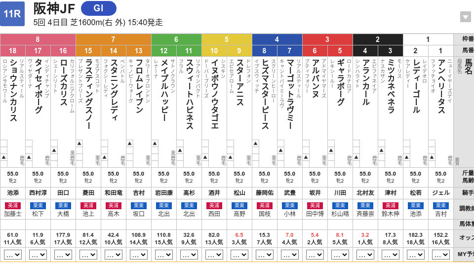

## 4. 単勝予測結果

### 【中日新聞杯(GⅢ) 2025/12/13(土)】

| 枠番 | 馬番 | 人気 | オッズ | 馬名 | 騎手 | 調教師 | 予測タイム(sec) | 1_順位 | 1-3着内確率(%) | 2_順位 | ﾀﾞｰｸﾎｰｽ確率(%) | 3_順位 |
| --- | --- | --- | --- | --- | --- | --- | --- | --- | --- | --- | --- | --- |
| 1 | 1 | 14 | 114.4 | ホウオウプロサンゲ | 吉田隼人 | 矢作芳人 | 133.1 | 16 | 6.1 | 14 | 42.7 | 5 |
| 1 | 2 | 13 | 110.8 | ウインエーデル | 西塚洸二 | 吉田直弘 | 130.4 | 9 | 9.2 | 11 | 48.6 | 4 |
| 2 | 3 | 5 | 9.5 | ジューンテイク | 藤岡佑介 | 武英智 | 130.6 | 10 | 25.4 | 4 | 0.6 | 17 |
| 2 | 4 | 1 | 4.6 | ファミリータイム | 松山弘平 | 石坂公一 | 118.7 | 3 | 26.2 | 2 | 0.6 | 15 |
| 3 | 5 | 9 | 20.9 | オニャンコポン | 菅原明良 | 小島茂之 | 118.7 | 3 | 17.1 | 9 | 1.1 | 12 |
| 3 | 6 | 10 | 21.0 | メリオーレム | 武豊 | 友道康夫 | 130.9 | 13 | 22.8 | 6 | 62.6 | 2 |
| 4 | 7 | 7 | 14.8 | レッドバリエンテ | 西村淳也 | 中内田充正 | 118.7 | 3 | 25.6 | 3 | 1.3 | 11 |
| 4 | 8 | 3 | 5.4 | シェイクユアハート | 古川吉洋 | 宮徹 | 118.7 | 3 | 18.8 | 8 | 0.4 | 18 |
| 5 | 9 | 4 | 6.1 | ピースワンデュック | 柴田善臣 | 大竹正博 | 126.0 | 6 | 50.7 | 1 | 0.6 | 13 |
| 5 | 10 | 12 | 44.7 | マイネルケレリウス | 丸山元気 | 奥村武 | 131.9 | 14 | 9.0 | 12 | 49.8 | 3 |

[output cut: 8 more lines]

### 【カペラステークス(GⅢ) 2025/12/14(日)】

| 枠番 | 馬番 | 人気 | オッズ | 馬名 | 騎手 | 調教師 | 予測タイム(sec) | 1_順位 | 1-3着内確率(%) | 2_順位 | ﾀﾞｰｸﾎｰｽ確率(%) | 3_順位 |
| --- | --- | --- | --- | --- | --- | --- | --- | --- | --- | --- | --- | --- |
| 1 | 1 | 6 | 11.0 | ドンアミティエ | 丹内祐次 | 今野貞一 | 73.8 | 10 | 27.0 | 5 | 1.4 | 9 |
| 1 | 2 | 13 | 79.1 | エートラックス | 内田博幸 | 宮本博 | 73.0 | 2 | 7.8 | 11 | 37.5 | 3 |
| 2 | 3 | 16 | 111.9 | スターペスカオリ | 長岡禎仁 | 石橋守 | 73.4 | 7 | 8.3 | 10 | 43.8 | 1 |
| 2 | 4 | 1 | 3.9 | テーオーエルビス | 鮫島克駿 | 高柳大輔 | 69.1 | 1 | 28.3 | 4 | 0.5 | 16 |
| 3 | 5 | 8 | 15.8 | サンライズアムール | 北村宏司 | 小林真也 | 77.1 | 13 | 7.2 | 12 | 0.8 | 14 |
| 3 | 6 | 2 | 6.1 | ポッドベイダー | 荻野極 | 上原佑紀 | 73.7 | 8 | 46.7 | 1 | 0.7 | 15 |
| 4 | 7 | 14 | 85.6 | キャンディドライヴ | 落合玄太 | 小野望 | 73.2 | 3 | 6.6 | 14 | 39.9 | 2 |
| 4 | 8 | 5 | 8.2 | クロジシジョー | 戸崎圭太 | 岡田稲男 | 78.7 | 16 | 10.8 | 7 | 1.2 | 10 |
| 5 | 9 | 3 | 6.3 | ガビーズシスター | 吉田隼人 | 森一誠 | 77.8 | 14 | 36.8 | 2 | 1.0 | 12 |
| 5 | 10 | 10 | 19.6 | タガノミスト | 佐々木大輔 | 渡辺薫彦 | 73.8 | 11 | 9.1 | 9 | 27.6 | 6 |

[output cut: 6 more lines]

### 【阪神ジュベナイルF(GⅠ) 2025/12/14(日)】

| 枠番 | 馬番 | 人気 | オッズ | 馬名 | 騎手 | 調教師 | 予測タイム(sec) | 1_順位 | 1-3着内確率(%) | 2_順位 | ﾀﾞｰｸﾎｰｽ確率(%) | 3_順位 |
| --- | --- | --- | --- | --- | --- | --- | --- | --- | --- | --- | --- | --- |
| 1 | 1 | 16 | 153.7 | アンヘリータス | Ｆ．ジェルー | 吉村圭司 | 98.9 | 8.5 | 14.6 | 13 | 70.2 | 5.0 |
| 1 | 2 | 18 | 181.1 | レディーゴール | 松若風馬 | 池添学 | 98.9 | 8.5 | 16.3 | 11 | 70.6 | 4.0 |
| 2 | 3 | 8 | 17.9 | ミツカネベネラ | 津村明秀 | 鈴木伸尋 | 99.3 | 17.0 | 23.0 | 9 | 4.4 | 13.0 |
| 2 | 4 | 1 | 3.2 | アランカール | 北村友一 | 斉藤崇史 | 93.9 | 1.0 | 24.0 | 8 | 4.4 | 14.5 |
| 3 | 5 | 5 | 8.0 | ギャラボーグ | 川田将雅 | 杉山晴紀 | 99.2 | 15.0 | 26.8 | 6 | 3.5 | 18.0 |
| 3 | 6 | 2 | 5.3 | アルバンヌ | 坂井瑠星 | 田中博康 | 98.5 | 2.0 | 31.2 | 1 | 4.4 | 14.5 |
| 4 | 7 | 4 | 7.0 | マーゴットラヴミー | 武豊 | 小林真也 | 99.0 | 14.0 | 24.6 | 7 | 6.1 | 10.0 |
| 4 | 8 | 7 | 15.0 | ヒズマスターピース | 藤岡佑介 | 国枝栄 | 99.3 | 18.0 | 27.1 | 5 | 3.9 | 17.0 |
| 5 | 9 | 3 | 6.4 | スターアニス | 松山弘平 | 高野友和 | 98.5 | 3.0 | 28.0 | 4 | 4.7 | 11.0 |
| 5 | 10 | 12 | 81.8 | イヌボウノウタゴエ | 酒井学 | 西田雄一郎 | 98.9 | 8.5 | 14.0 | 14 | 60.1 | 8.0 |

[output cut: 8 more lines]

## 5. 人気と着順の乖離率推移

### 【中日新聞杯_1990y_2019y】

[interactive chart not shown]

### 【カペラステークス_2008y_2019y】

[interactive chart not shown]

### 【阪神ジュベナイルF_2001y_2019y】

[interactive chart not shown]

### 【中日新聞杯_1990y_2019y】

| No | 開催年 | 不整合率(%) | 頭数 | 人気別着順(1-3位) | 人気別着順(全体) |
| --- | --- | --- | --- | --- | --- |
| 30 | 2019 | 53.9 | 16頭 | 8-3-2 | 8\|3\|2\|10\|5\|13\|6\|15\|1\|12\|11\|4\|7\|9\|16\|14 |
| 29 | 2018 | 31.8 | 14頭 | 1-12-7 | 1\|12\|7\|8\|3\|6\|13\|2\|10\|4\|9\|11\|5\|14 |
| 28 | 2017 | 28.9 | 18頭 | 2-1-5 | 2\|1\|5\|9\|4\|3\|11\|17\|6\|14\|13\|15\|10\|8\|7\|16\|12\|18 |
| 27 | 2016 | 29.5 | 18頭 | 1-9-13 | 1\|9\|13\|5\|6\|2\|12\|8\|4\|3\|10\|11\|16\|14\|17\|15\|18\|7 |
| 26 | 2015 | 44.7 | 18頭 | 5-2-6 | 5\|2\|6\|7\|3\|9\|1\|4\|10\|14\|13\|15\|12\|18\|16\|8\|17\|11 |
| 25 | 2014 | 55.0 | 18頭 | 10-3-4 | 10\|3\|4\|8\|12\|2\|1\|6\|9\|5\|14\|13\|15\|18\|17\|11\|7\|16 |
| 24 | 2013 | 34.3 | 17頭 | 5-1-3 | 5\|1\|3\|4\|11\|6\|7\|2\|13\|9\|16\|12\|17\|18\|15\|8\|14 |
| 23 | 2012 | 50.0 | 16頭 | 6-9-1 | 6\|9\|1\|5\|7\|4\|17\|14\|3\|11\|8\|12\|10\|13\|2\|16 |
| 22 | 2011 | 37.5 | 18頭 | 11-4-2 | 11\|4\|2\|1\|12\|5\|6\|3\|16\|7\|13\|14\|10\|18\|15\|9\|8\|17 |
| 21 | 2010 | 25.7 | 18頭 | 1-6-4 | 1\|6\|4\|13\|7\|2\|16\|17\|3\|5\|11\|10\|9\|12\|18\|14\|15\|8 |

[output cut: 20 more lines]

### 【カペラステークス_2008y_2019y】

| No | 開催年 | 不整合率(%) | 頭数 | 人気別着順(1-3位) | 人気別着順(全体) |
| --- | --- | --- | --- | --- | --- |
| 12 | 2019 | 33.5 | 16頭 | 2-3-7 | 2\|3\|7\|6\|1\|4\|8\|5\|10\|9\|16\|11\|12\|13\|14\|15 |
| 11 | 2018 | 21.3 | 16頭 | 1-11-2 | 1\|11\|2\|8\|10\|7\|12\|3\|5\|9\|6\|4\|13\|16\|15\|14 |
| 10 | 2017 | 48.0 | 16頭 | 4-8-2 | 4\|8\|2\|11\|5\|9\|16\|6\|13\|1\|15\|14\|10\|12\|3\|7 |
| 9 | 2016 | 38.5 | 16頭 | 3-2-1 | 3\|2\|1\|8\|4\|16\|9\|5\|6\|7\|10\|15\|11\|12\|13\|14 |
| 8 | 2015 | 51.8 | 16頭 | 3-4-6 | 3\|4\|6\|7\|8\|13\|5\|1\|9\|11\|2\|14\|15\|10\|12\|16 |
| 7 | 2014 | 48.1 | 15頭 | 12-7-8 | 12\|7\|8\|5\|4\|1\|10\|6\|14\|2\|11\|3\|13\|15\|9 |
| 6 | 2013 | 46.7 | 16頭 | 6-7-2 | 6\|7\|2\|3\|4\|10\|8\|14\|1\|12\|5\|9\|15\|11\|13\|16 |
| 5 | 2012 | 55.5 | 16頭 | 4-3-8 | 4\|3\|8\|12\|1\|7\|6\|14\|5\|15\|13\|9\|2\|11\|10\|16 |
| 4 | 2011 | 39.2 | 15頭 | 2-3-8 | 2\|3\|8\|4\|1\|10\|7\|6\|14\|13\|5\|12\|9\|11\|15 |
| 3 | 2010 | 46.6 | 16頭 | 3-13-5 | 3\|13\|5\|1\|9\|4\|7\|6\|15\|8\|14\|2\|11\|12\|16\|10 |

[output cut: 2 more lines]

### 【阪神ジュベナイルF_2001y_2019y】

| No | 開催年 | 不整合率(%) | 頭数 | 人気別着順(1-3位) | 人気別着順(全体) |
| --- | --- | --- | --- | --- | --- |
| 19 | 2019 | 61.1 | 16頭 | 4-6-3 | 4\|6\|3\|2\|7\|1\|13\|5\|11\|10\|12\|8\|15\|16\|14\|9 |
| 18 | 2018 | 12.5 | 18頭 | 1-2-4 | 1\|2\|4\|3\|14\|7\|5\|15\|6\|12\|17\|13\|10\|16\|8\|11\|9\|18 |
| 17 | 2017 | 39.2 | 18頭 | 2-3-4 | 2\|3\|4\|7\|10\|9\|13\|5\|1\|11\|15\|14\|6\|8\|18\|17\|16\|12 |
| 16 | 2016 | 9.4 | 18頭 | 1-2-3 | 1\|2\|3\|5\|6\|14\|7\|8\|18\|17\|4\|13\|10\|9\|12\|11\|15\|16 |
| 15 | 2015 | 27.0 | 18頭 | 1-10-3 | 1\|10\|3\|9\|4\|15\|2\|7\|5\|6\|14\|11\|8\|12\|13\|16\|17\|18 |
| 14 | 2014 | 42.6 | 18頭 | 5-2-4 | 5\|2\|4\|12\|11\|13\|7\|1\|8\|3\|15\|14\|6\|9\|18\|16\|10\|17 |
| 13 | 2013 | 34.5 | 18頭 | 5-1-8 | 5\|1\|8\|7\|4\|6\|2\|10\|3\|9\|18\|11\|17\|16\|12\|15\|14\|13 |
| 12 | 2012 | 39.4 | 18頭 | 5-15-10 | 5\|15\|10\|1\|7\|6\|4\|2\|8\|14\|18\|17\|12\|11\|13\|9\|3\|16 |
| 11 | 2011 | 35.5 | 18頭 | 4-8-1 | 4\|8\|1\|5\|10\|14\|15\|2\|13\|9\|6\|7\|16\|12\|3\|18\|17\|11 |
| 10 | 2010 | 33.4 | 18頭 | 1-4-8 | 1\|4\|8\|3\|11\|6\|14\|10\|2\|15\|5\|7\|13\|18\|9\|16\|12\|17 |

[output cut: 9 more lines]

## 6. 1-3番人気馬の着順分類予測

### 【中日新聞杯】

| 分類 | 凡例 | 発生確率(%) | 当該レース | 当該レースランク | 直近1年間 |
| --- | --- | --- | --- | --- | --- |
| 1: 1番人気のみ (1_pop1) | 1 \| * \| * | 16.7 | 0.73 | 0.97 | 0.00 |
| 4: 1,2番人気のみ (4_pop12) | 1 \| 2 \| * | 16.6 | 1.16 | 1.44 | 0.00 |
| 8: 1,2,3番人気すべて着外 (8_darkhorse) | * \| * \| * | 14.3 | 2.51 | 1.86 | 0.00 |
| 5: 1,3番人気のみ (5_pop13) | 1 \| 3 \| * | 13.9 | 2.44 | 3.66 | 0.00 |
| 6: 2,3番人気のみ (6_pop23) | 2 \| 3 \| * | 12.0 | 0.42 | 0.37 | 0.18 |
| 2: 2番人気のみ (2_pop2) | 2 \| * \| * | 9.8 | 0.69 | 0.73 | 0.00 |
| 3: 3番人気のみ (3_pop3) | 3 \| * \| * | 9.4 | 1.09 | 0.82 | 0.28 |
| 7: 1,2,3番人気すべて着内 (7_pop123) | 1 \| 2 \| 3 | 7.3 | 0.00 | 3.84 | 0.00 |

### 【カペラステークス】

| 分類 | 凡例 | 発生確率(%) | 当該レース | 当該レースランク | 直近1年間 |
| --- | --- | --- | --- | --- | --- |
| 1: 1番人気のみ (1_pop1) | 1 \| * \| * | 16.7 | 2.83 | 2.83 | 0.00 |
| 4: 1,2番人気のみ (4_pop12) | 1 \| 2 \| * | 16.6 | 2.81 | 2.81 | 0.00 |
| 8: 1,2,3番人気すべて着外 (8_darkhorse) | * \| * \| * | 14.3 | 1.21 | 1.21 | 0.00 |
| 5: 1,3番人気のみ (5_pop13) | 1 \| 3 \| * | 13.9 | 0.00 | 0.00 | 0.00 |
| 6: 2,3番人気のみ (6_pop23) | 2 \| 3 \| * | 12.0 | 0.29 | 0.29 | 0.24 |
| 2: 2番人気のみ (2_pop2) | 2 \| * \| * | 9.8 | 0.83 | 0.83 | 0.00 |
| 3: 3番人気のみ (3_pop3) | 3 \| * \| * | 9.4 | 0.53 | 0.53 | 0.19 |
| 7: 1,2,3番人気すべて着内 (7_pop123) | 1 \| 2 \| 3 | 7.3 | 1.24 | 1.24 | 0.00 |

### 【阪神ジュベナイルF】

| 分類 | 凡例 | 発生確率(%) | 当該レース | 当該レースランク | 直近1年間 |
| --- | --- | --- | --- | --- | --- |
| 1: 1番人気のみ (1_pop1) | 1 \| * \| * | 16.8 | 1.01 | 1.01 | 0.00 |
| 4: 1,2番人気のみ (4_pop12) | 1 \| 2 \| * | 16.6 | 2.00 | 2.00 | 0.00 |
| 8: 1,2,3番人気すべて着外 (8_darkhorse) | * \| * \| * | 14.3 | 1.72 | 1.72 | 0.00 |
| 5: 1,3番人気のみ (5_pop13) | 1 \| 3 \| * | 14.0 | 1.12 | 1.12 | 0.00 |
| 6: 2,3番人気のみ (6_pop23) | 2 \| 3 \| * | 11.7 | 1.41 | 1.41 | 0.23 |
| 2: 2番人気のみ (2_pop2) | 2 \| * \| * | 9.8 | 0.59 | 0.59 | 0.00 |
| 3: 3番人気のみ (3_pop3) | 3 \| * \| * | 9.5 | 0.38 | 0.38 | 0.19 |
| 7: 1,2,3番人気すべて着内 (7_pop123) | 1 \| 2 \| 3 | 7.3 | 1.74 | 1.74 | 0.00 |

## 7. 3連複予測結果

### 【中日新聞杯(GⅢ) 2025/12/13(土)】

| 分類 | 馬番 | 枠番 | 人気 | 平均予測タイム(sec) | 1-3着内確率(%) | ﾀﾞｰｸﾎｰｽ確率(%) | 馬名 | 騎手 | 調教師 |
| --- | --- | --- | --- | --- | --- | --- | --- | --- | --- |
| 1: 1番人気のみ (1_pop1) | 4-9-7 | 2-5-4 | 1-4-7 | 121.13 | 3.40 | 0.00 | ファミリータイム \| ピースワンデュック \| レッドバリエンテ | 松山弘平 \| 柴田善臣 \| 西村淳也 | 石坂公一 \| 大竹正博 \| 中内田充正 |
| 1: 1番人気のみ (1_pop1) | 4-9-3 | 2-5-2 | 1-4-5 | 125.10 | 3.38 | 0.00 | ファミリータイム \| ピースワンデュック \| ジューンテイク | 松山弘平 \| 柴田善臣 \| 藤岡佑介 | 石坂公一 \| 大竹正博 \| 武英智 |
| 8: 1,2,3番人気すべて着外 (8_darkhorse) | 9-3-7 | 5-2-4 | 4-5-7 | 125.10 | 3.29 | 0.00 | ピースワンデュック \| ジューンテイク \| レッドバリエンテ | 柴田善臣 \| 藤岡佑介 \| 西村淳也 | 大竹正博 \| 武英智 \| 中内田充正 |
| 4: 1,2番人気のみ (4_pop12) | 4-14-9 | 2-7-5 | 1-2-4 | 121.13 | 3.20 | 0.00 | ファミリータイム \| シンハナーダ \| ピースワンデュック | 松山弘平 \| 鮫島克駿 \| 柴田善臣 | 石坂公一 \| 国枝栄 \| 大竹正博 |
| 2: 2番人気のみ (2_pop2) | 14-9-7 | 7-5-4 | 2-4-7 | 121.13 | 3.11 | 0.00 | シンハナーダ \| ピースワンデュック \| レッドバリエンテ | 鮫島克駿 \| 柴田善臣 \| 西村淳也 | 国枝栄 \| 大竹正博 \| 中内田充正 |
| 2: 2番人気のみ (2_pop2) | 14-9-3 | 7-5-2 | 2-4-5 | 125.10 | 3.09 | 0.00 | シンハナーダ \| ピースワンデュック \| ジューンテイク | 鮫島克駿 \| 柴田善臣 \| 藤岡佑介 | 国枝栄 \| 大竹正博 \| 武英智 |
| 1: 1番人気のみ (1_pop1) | 4-9-6 | 2-5-3 | 1-4-10 | 125.20 | 3.03 | 0.00 | ファミリータイム \| ピースワンデュック \| メリオーレム | 松山弘平 \| 柴田善臣 \| 武豊 | 石坂公一 \| 大竹正博 \| 友道康夫 |
| 8: 1,2,3番人気すべて着外 (8_darkhorse) | 9-7-6 | 5-4-3 | 4-7-10 | 125.20 | 2.95 | 0.01 | ピースワンデュック \| レッドバリエンテ \| メリオーレム | 柴田善臣 \| 西村淳也 \| 武豊 | 大竹正博 \| 中内田充正 \| 友道康夫 |
| 8: 1,2,3番人気すべて着外 (8_darkhorse) | 9-3-6 | 5-2-3 | 4-5-10 | 129.17 | 2.93 | 0.00 | ピースワンデュック \| ジューンテイク \| メリオーレム | 柴田善臣 \| 藤岡佑介 \| 武豊 | 大竹正博 \| 武英智 \| 友道康夫 |
| 2: 2番人気のみ (2_pop2) | 14-9-6 | 7-5-3 | 2-4-10 | 125.20 | 2.78 | 0.00 | シンハナーダ \| ピースワンデュック \| メリオーレム | 鮫島克駿 \| 柴田善臣 \| 武豊 | 国枝栄 \| 大竹正博 \| 友道康夫 |

[output cut: 806 more lines]

### 【カペラステークス(GⅢ) 2025/12/14(日)】

| 分類 | 馬番 | 枠番 | 人気 | 平均予測タイム(sec) | 1-3着内確率(%) | ﾀﾞｰｸﾎｰｽ確率(%) | 馬名 | 騎手 | 調教師 |
| --- | --- | --- | --- | --- | --- | --- | --- | --- | --- |
| 6: 2,3番人気のみ (6_pop23) | 6-9-16 | 3-5-8 | 2-3-4 | 74.97 | 5.34 | 0.00 | ポッドベイダー \| ガビーズシスター \| ヤマニンチェルキ | 荻野極 \| 吉田隼人 \| 岩田望来 | 上原佑紀 \| 森一誠 \| 中村直也 |
| 7: 1,2,3番人気すべて着内 (7_pop123) | 4-6-9 | 2-3-5 | 1-2-3 | 73.53 | 4.87 | 0.00 | テーオーエルビス \| ポッドベイダー \| ガビーズシスター | 鮫島克駿 \| 荻野極 \| 吉田隼人 | 高柳大輔 \| 上原佑紀 \| 森一誠 |
| 6: 2,3番人気のみ (6_pop23) | 6-9-1 | 3-5-1 | 2-3-6 | 75.10 | 4.63 | 0.00 | ポッドベイダー \| ガビーズシスター \| ドンアミティエ | 荻野極 \| 吉田隼人 \| 丹内祐次 | 上原佑紀 \| 森一誠 \| 今野貞一 |
| 4: 1,2番人気のみ (4_pop12) | 4-6-16 | 2-3-8 | 1-2-4 | 72.07 | 4.11 | 0.00 | テーオーエルビス \| ポッドベイダー \| ヤマニンチェルキ | 鮫島克駿 \| 荻野極 \| 岩田望来 | 高柳大輔 \| 上原佑紀 \| 中村直也 |
| 2: 2番人気のみ (2_pop2) | 6-16-1 | 3-8-1 | 2-4-6 | 73.63 | 3.91 | 0.00 | ポッドベイダー \| ヤマニンチェルキ \| ドンアミティエ | 荻野極 \| 岩田望来 \| 丹内祐次 | 上原佑紀 \| 中村直也 \| 今野貞一 |
| 6: 2,3番人気のみ (6_pop23) | 6-9-11 | 3-5-6 | 2-3-7 | 75.07 | 3.70 | 0.00 | ポッドベイダー \| ガビーズシスター \| チカッパ | 荻野極 \| 吉田隼人 \| 横山典弘 | 上原佑紀 \| 森一誠 \| 中竹和也 |
| 4: 1,2番人気のみ (4_pop12) | 4-6-1 | 2-3-1 | 1-2-6 | 72.20 | 3.56 | 0.00 | テーオーエルビス \| ポッドベイダー \| ドンアミティエ | 鮫島克駿 \| 荻野極 \| 丹内祐次 | 高柳大輔 \| 上原佑紀 \| 今野貞一 |
| 5: 1,3番人気のみ (5_pop13) | 4-9-16 | 2-5-8 | 1-3-4 | 73.43 | 3.24 | 0.00 | テーオーエルビス \| ガビーズシスター \| ヤマニンチェルキ | 鮫島克駿 \| 吉田隼人 \| 岩田望来 | 高柳大輔 \| 森一誠 \| 中村直也 |
| 2: 2番人気のみ (2_pop2) | 6-16-11 | 3-8-6 | 2-4-7 | 73.60 | 3.12 | 0.00 | ポッドベイダー \| ヤマニンチェルキ \| チカッパ | 荻野極 \| 岩田望来 \| 横山典弘 | 上原佑紀 \| 中村直也 \| 中竹和也 |
| 3: 3番人気のみ (3_pop3) | 9-16-1 | 5-8-1 | 3-4-6 | 75.00 | 3.08 | 0.00 | ガビーズシスター \| ヤマニンチェルキ \| ドンアミティエ | 吉田隼人 \| 岩田望来 \| 丹内祐次 | 森一誠 \| 中村直也 \| 今野貞一 |

[output cut: 550 more lines]

### 【阪神ジュベナイルF(GⅠ) 2025/12/14(日)】

| 分類 | 馬番 | 枠番 | 人気 | 平均予測タイム(sec) | 1-3着内確率(%) | ﾀﾞｰｸﾎｰｽ確率(%) | 馬名 | 騎手 | 調教師 |
| --- | --- | --- | --- | --- | --- | --- | --- | --- | --- |
| 2: 2番人気のみ (2_pop2) | 6-17-18 | 3-8-8 | 2-6-11 | 98.90 | 2.56 | 0.11 | アルバンヌ \| タイセイボーグ \| ショウナンカリス | 坂井瑠星 \| 西村淳也 \| 池添謙一 | 田中博康 \| 松下武士 \| 加藤士津八 |
| 6: 2,3番人気のみ (6_pop23) | 6-9-18 | 3-5-8 | 2-3-11 | 98.63 | 2.54 | 0.13 | アルバンヌ \| スターアニス \| ショウナンカリス | 坂井瑠星 \| 松山弘平 \| 池添謙一 | 田中博康 \| 高野友和 \| 加藤士津八 |
| 6: 2,3番人気のみ (6_pop23) | 6-9-17 | 3-5-8 | 2-3-6 | 98.77 | 2.47 | 0.01 | アルバンヌ \| スターアニス \| タイセイボーグ | 坂井瑠星 \| 松山弘平 \| 西村淳也 | 田中博康 \| 高野友和 \| 松下武士 |
| 2: 2番人気のみ (2_pop2) | 6-8-18 | 3-4-8 | 2-7-11 | 98.90 | 2.46 | 0.10 | アルバンヌ \| ヒズマスターピース \| ショウナンカリス | 坂井瑠星 \| 藤岡佑介 \| 池添謙一 | 田中博康 \| 国枝栄 \| 加藤士津八 |
| 2: 2番人気のみ (2_pop2) | 6-5-18 | 3-3-8 | 2-5-11 | 98.87 | 2.44 | 0.09 | アルバンヌ \| ギャラボーグ \| ショウナンカリス | 坂井瑠星 \| 川田将雅 \| 池添謙一 | 田中博康 \| 杉山晴紀 \| 加藤士津八 |
| 2: 2番人気のみ (2_pop2) | 6-17-8 | 3-8-4 | 2-6-7 | 99.03 | 2.40 | 0.01 | アルバンヌ \| タイセイボーグ \| ヒズマスターピース | 坂井瑠星 \| 西村淳也 \| 藤岡佑介 | 田中博康 \| 松下武士 \| 国枝栄 |
| 6: 2,3番人気のみ (6_pop23) | 6-9-8 | 3-5-4 | 2-3-7 | 98.77 | 2.37 | 0.01 | アルバンヌ \| スターアニス \| ヒズマスターピース | 坂井瑠星 \| 松山弘平 \| 藤岡佑介 | 田中博康 \| 高野友和 \| 国枝栄 |
| 2: 2番人気のみ (2_pop2) | 6-5-17 | 3-3-8 | 2-5-6 | 99.00 | 2.37 | 0.01 | アルバンヌ \| ギャラボーグ \| タイセイボーグ | 坂井瑠星 \| 川田将雅 \| 西村淳也 | 田中博康 \| 杉山晴紀 \| 松下武士 |
| 6: 2,3番人気のみ (6_pop23) | 6-9-5 | 3-5-3 | 2-3-5 | 98.73 | 2.35 | 0.01 | アルバンヌ \| スターアニス \| ギャラボーグ | 坂井瑠星 \| 松山弘平 \| 川田将雅 | 田中博康 \| 高野友和 \| 杉山晴紀 |
| 3: 3番人気のみ (3_pop3) | 9-17-18 | 5-8-8 | 3-6-11 | 98.90 | 2.30 | 0.11 | スターアニス \| タイセイボーグ \| ショウナンカリス | 松山弘平 \| 西村淳也 \| 池添謙一 | 高野友和 \| 松下武士 \| 加藤士津八 |

[output cut: 806 more lines]

## 8. 直近の全レース情報

[output not shown]

[output cut: 9 more lines]